# Some Properties of the Empirical Payoff Quantal Response Equilibrium Estimator

2020-09-11

## Quantal Response Equilibrium fixed point

A probabilistic best response function \(q(\lambda,\sigma,U)\)

(log) probability of choosing each action given choice precision \(\lambda\), (log) opponents’ mixed strategies \(\sigma\), and payoffs \(U\) \[ \begin{aligned} \text{e.g.}\quad q_{i,a}(\lambda,\sigma,U)&=\log\left(\frac{\exp(\lambda U_{i,a}\sigma_{-i})}{\sum_{b\in A_i}\exp(\lambda U_{i,b}\sigma_{-i})}\right) \end{aligned} \]

[figure not shown]

## Estimation using the fixed point condition

A fixed point in probabilistic responses (rather than best responses)

\[ Q(\lambda)=q(\lambda,Q(\lambda),U) \] - \(Q(\lambda)\) is a vector of (log) probabilities.

Maximum likelihood estimation: \[ \hat\lambda^\text{Fixed}=\arg\max_{\lambda\geq 0} Q(\lambda)^\top y \] - \(y\) is a vector of count data for each action

This is what I used in my previous presentation

## The fixed point estimator is computationally difficult

\[ \hat\lambda^\text{Fixed}=\arg\max_{\lambda\geq 0} Q(\lambda)^\top y \] Usually:

- No closed-form solution
- Unstable (iteration doesn’t work): \[ Q_{k+1}=q(\lambda,Q_k,U)\]
- Even more difficult when adding other parameters (risk aversion, etc)

## Empirical payoff approach: a shortcut!

If subjects are playing QRE: \[\hat\sigma_{i,a} = \frac{y_{i,a}}{n_i} =\text{fraction of times player $i$ chooses action $a$}\] \[\mathrm{plim}(\hat\sigma)=Q(\lambda)\]

Therefore \(\hat\sigma\) *should* be a good approximation of \(Q(\lambda)\).

\[\hat\lambda^\text{Empirical} = \arg\max_{\lambda\geq0}q(\lambda,\hat\sigma,U)^\top y\]

A similar shortcut is also used in empirical IO (dynamic programming): \[ V(x_t;\theta)=\max_a\left\{u(a,x_t;\theta) + \beta E\left[V(x_{t+1}(a),\theta)\right]\right\} \]

## Comparing the estimators

\[ \begin{aligned} \hat\lambda^\text{Fixed}&=\arg\max_{\lambda\geq 0} Q(\lambda)^\top y \\ &=\arg\max_{\lambda\geq0}q(\lambda,Q(\lambda),U)^\top y\\ \\ \hat\lambda^\text{Empirical} &= \arg\max_{\lambda\geq0}q(\lambda,\hat\sigma,U)^\top y \end{aligned} \]

\(\hat\lambda^\text{Empirical}\) avoids computing the fixed point, and since \(\mathrm{plim}(\hat\sigma)=Q(\lambda)\), it must be that \[\mathrm{plim}\left(\hat\lambda^\text{Empirical}\right)=\mathrm{plim}\left(\hat\lambda^\text{Fixed}\right)\]

\(\mathrm{plim}\left(\hat\lambda^\text{Empirical}\right)=\mathrm{plim}\left(\hat\lambda^\text{Fixed}\right)\) is good if:

- \(N\to\infty\), and
- Subjects are actually playing QRE

If \(\hat\sigma\) is not close to \(Q(\lambda)\), will \(\hat\lambda^\text{Empirical}\approx\hat\lambda^\text{Fixed}\)?

- Generally no
- \(\hat\lambda^\text{Empirical}\) performs especially badly when \(\hat\sigma\) is close to Nash equilibrium

How well does \(\hat\lambda^\text{Empirical}\) actually work?

- Evaluate out-of-sample prediction error
- \(\hat\lambda^\text{Fixed}\) outperforms \(\hat\lambda^\text{Empirical}\) in my application

## An example: Selten & Chmura (2008)

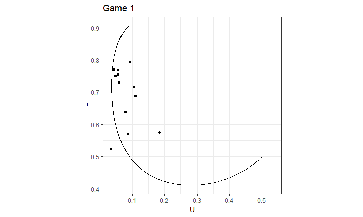

## Contours of the estimators

Consider the set of empirical choice probabilities that result in the same estimate for \(\lambda^\text{Fixed}\) and \(\lambda^\text{Empirical}\)

- These contours overlap along the QRE path \(Q(\lambda)\)
- They do not necessarily overlap anywhere else
- \(\lambda^\text{Empirical}\) performs particularly badly when choice probabilities are closed to a Mixed Strategy Nash equilibrium. *Intuition*: Player is almost indifferent between all actions means that probabilistic best response is close to uniform randomization for all but the largest values of \(\lambda\)

Proof involves cross-partial derivative of the likelihood functions wrt \(\lambda\) and \(\hat\sigma\).

I found it much easier to understand with plots.

## Game 1 of Selten & Chmura (2008)

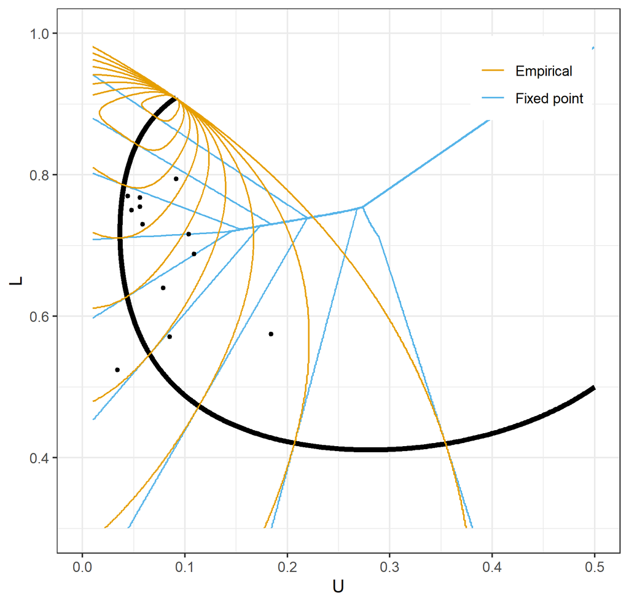

- Similar for choices close to QRE
- Large differences away from QRE
- \(\hat\lambda^\text{Empirical}\) contours all cross the Nash equilibrium

*How well do \(\hat\lambda^\text{Fixed}\) and \(\hat\lambda^\text{Empirical}\) do in making out-of-sample predictions?*

## Leave-one-out cross-validation

For every game \(g=1, 2, 3, \ldots, 12\)

- Estimate \(\hat\lambda^\text{Fixed}_{-g}\) and \(\hat\lambda^\text{Empirical}_{-g}\), using all data except game \(g\)
- Use these to predict choice probabilities for game \(g\)

Assess each estimator’s ability to make out-of-sample predictions

\[ \text{Root mean squared prediction error}=\sqrt{\frac{1}{2G}\sum_{g=1}^g\sum_{a\in\{U,L\}}\left(Q_{g,a}(\hat\lambda)-\hat\sigma_{g,a}\right)^2} \]

## Out-of-sample predictions

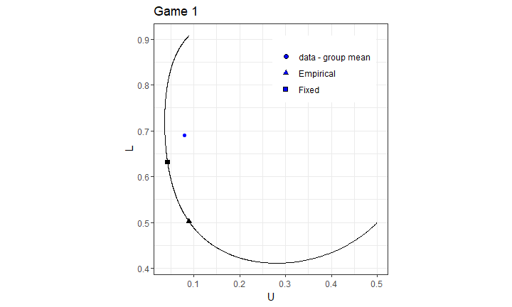

## Results

| Method | RMSE |
| --- | --- |
| Random | 0.4864862 |
| Nash | 0.3762767 |
| Fixed point | 0.1341846 |
| Empirical Payoff | 0.2003889 |

## Conclusions

- Predictions using \(\hat\lambda^\text{Fixed}\) and \(\hat\lambda^\text{Empirical}\) could be different
- Particularly so when data are not close to QRE
- Leave-one-out cross-validation using data from asymmetric matching pennies games concludes that the fixed point method outperforms the empirical payoff approach.